# Capstone Repo - Week 1-2, including Milestone Report

J Balvers

13 mei 2017

This .Rmd file covers the tasks and the Milestone Report for the first two weeks of the Data Science Capstone.

## Week 1

Tasks to accomplish

- Tokenization - identifying appropriate tokens such as words, punctuation, and numbers. Writing a function that takes a file as input and returns a tokenized version of it.
- Profanity filtering - removing profanity and other words you do not want to predict.

First we will import the data and do some statistics on the files themselves about size and word count and line length.

```r
## this is the code for week 1 exploration
# import the blogs and twitter datasets in text mode
blogs <- readLines("final/en_US/en_US.blogs.txt", encoding="UTF-8")
twitter <- readLines("final/en_US/en_US.twitter.txt", encoding="UTF-8")
# import the news dataset in binary mode
con <- file("final/en_US/en_US.news.txt", open="rb")
news <- readLines(con, encoding="UTF-8")
close(con)
rm(con)

# file size (in MegaBytes/MB)
file.info("final/en_US/en_US.blogs.txt")$size   / 1024^2
```

```
## [1] 200.4242
```

```r
file.info("final/en_US/en_US.news.txt")$size    / 1024^2
```

```
## [1] 196.2775
```

```r
file.info("final/en_US/en_US.twitter.txt")$size / 1024^2
```

```
## [1] 159.3641
```

```r
# general stats
stats_b <- stri_stats_general( blogs )
stats_n <- stri_stats_general( news )
stats_t <- stri_stats_general( twitter )

# count words per line
words_blogs   <- stri_count_words(blogs)
summary( words_blogs )
```

```
##    Min. 1st Qu.  Median    Mean 3rd Qu.    Max.
##    0.00    9.00   28.00   41.75   60.00 6726.00
```

```r
words_news    <- stri_count_words(news)
summary( words_news )
```

```
##    Min. 1st Qu.  Median    Mean 3rd Qu.    Max.
##    1.00   19.00   32.00   34.41   46.00 1796.00
```

```r
words_twitter <- stri_count_words(twitter)
summary( words_twitter )
```

```
##    Min. 1st Qu.  Median    Mean 3rd Qu.    Max.
##    1.00    7.00   12.00   12.75   18.00   47.00
```

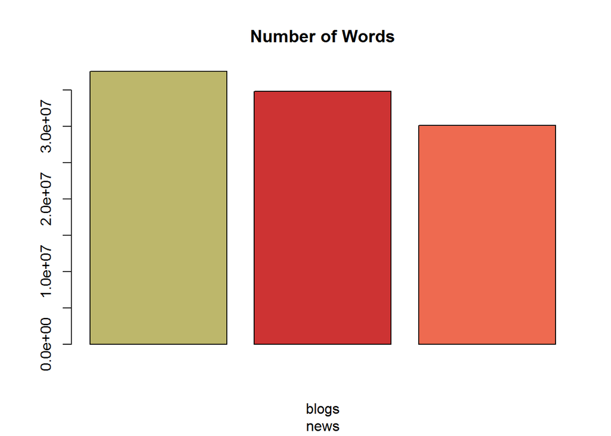

```r
# plot the number of words in a barplot
barplot(c(sum(words_blogs), sum(words_news), sum(words_twitter)), main="Number of Words", xlab=c("blogs", "news","twitter"), col=c("darkkhaki","brown3", "coral2"), beside=TRUE )
```

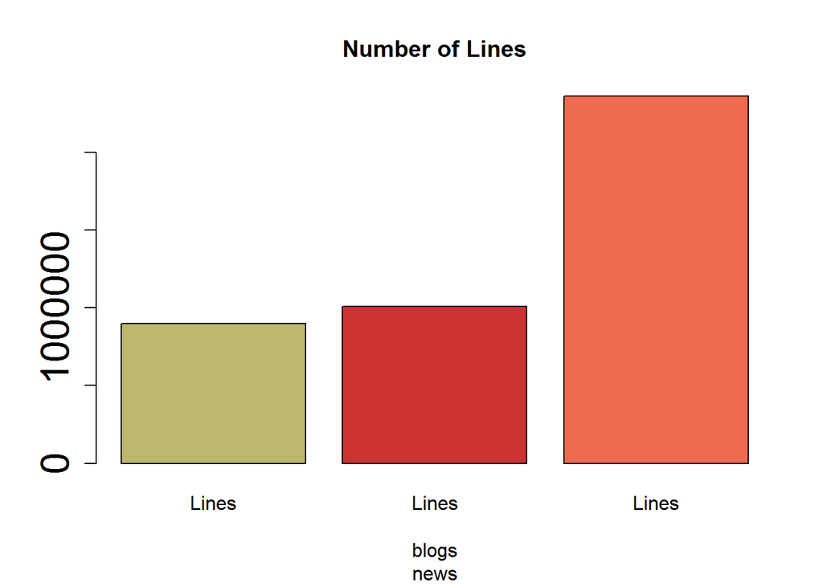

```r
# plot the number of lines per file in a barplot
barplot(c(stats_b[1], stats_n[1], stats_t[1]), main="Number of Lines", xlab=c("blogs", "news","twitter"), col=c("darkkhaki","brown3", "coral2"),  beside=TRUE, cex.axis=2)
```

### Taking a sample from the datasets

```r
## set the seed before taking the sample for reproducibility
set.seed(3531)

# take a 2% sample of the data
sample_blogs <- blogs[rbinom(length(blogs)*0.02,length(blogs),0.5)]
sample_news    <- news[rbinom(length(news)*0.02,length(news),0.5)]
sample_twitter <- twitter[rbinom(length(twitter)*0.02,length(twitter),0.5)]

save(sample_blogs, sample_news, sample_twitter, file= "sample_data.RData")
```

### Cleaning up the data

Now I’ll transform the files into three separate VCorpusses (VCorpi?) and apply a number of data cleaning steps. After these steps I save the intermediate results for later reference.

```r
## load required packages
library(magrittr)
library(tm)
library(RWeka)## create a corpus for each file and create a combined corpus:
# blogs
sample_blogs %>%
  data.frame() %>%
  DataframeSource() %>%
  VCorpus %>%
  tm_map( stripWhitespace ) -> vc_blogs

# news
sample_news %>%
  data.frame() %>%
  DataframeSource() %>%
  VCorpus %>%
  tm_map( stripWhitespace ) -> vc_news

# twitter
sample_twitter %>%
  data.frame() %>%
  DataframeSource() %>%
  VCorpus %>%
  tm_map( stripWhitespace ) -> vc_twitter

vc_all <- c(vc_blogs, vc_news, vc_twitter)

save(vc_blogs, vc_news, vc_twitter, vc_all, file= "vCorpus.RData")

# remove punctuation, numbers, other 'strange' characters and stopwords, per vc
# And: filter out profanity words using an open source list from http://www.bannedwordlist.com/
  url = "http://www.bannedwordlist.com/lists/swearWords.csv"
  download.file(url, "swearWords.csv", method= "auto", quiet = FALSE, mode = "w", cacheOK = TRUE)
  profanity = read.csv("./swearWords.csv")
vc_clean_blogs = vc_blogs %>%
    tm_map(removePunctuation) %>%
    tm_map(removeNumbers) %>%
    tm_map(content_transformer(function(x) iconv(x, to="UTF-8", sub="byte"))) %>%
    tm_map(removeWords, stopwords("english")) %>%
    tm_map(removeWords, profanity)

vc_clean_news = vc_news %>%
    tm_map(removePunctuation) %>%
    tm_map(removeNumbers) %>%
    tm_map(content_transformer(function(x) iconv(x, to="UTF-8", sub="byte"))) %>%
    tm_map(removeWords, stopwords("english")) %>%
    tm_map(removeWords, profanity)

vc_clean_twitter = vc_twitter %>%
    tm_map(removePunctuation) %>%
    tm_map(removeNumbers) %>%
    tm_map(content_transformer(function(x) iconv(x, to="UTF-8", sub="byte"))) %>%
    tm_map(removeWords, stopwords("english")) %>%
    tm_map(removeWords, profanity)

# Combine the three vc's into one
vc_clean_all <- c(vc_clean_blogs, vc_clean_news, vc_clean_twitter)

# Save the results for later access
save(vc_clean_blogs, vc_clean_news, vc_clean_twitter, vc_clean_all, file= "vCorpus_clean.RData")
```

### Tokenization

Here I create tokenized versions of the datasets in a couple of different levels: bi- tri- and four-gram.

```r
## create tokenized versions of the corpus (bi-gram and tri-gram)
BiGramTokenizer <- function(x) NGramTokenizer(x, Weka_control(min = 2, max = 2))
TriGramTokenizer <- function(x) NGramTokenizer(x, Weka_control(min = 3, max = 3))
FourGramTokenizer <- function(x) NGramTokenizer(x, Weka_control(min = 4, max = 4))

## Bi-gram tokenization
vc_clean_all %>%
  TermDocumentMatrix( control = list(
                                     removeSparseTerms=0.8,
                                     tokenize = BiGramTokenizer)
                      ) -> tdm_bigram

  # save the tdm for later use
  tdm_bigram %>%
    save( file = "tdm_bigram.RData" )

  # list bi-grams with at least 25 occurances
  tdm_bigram %>%
    findFreqTerms( lowfreq=25 ) -> bigrams
  bigrams
```

```
##    [1] "a child"
##    [2] "a couple"
##    [3] "a day"
##    [4] "a former"
##    [5] "a little"
##    [6] "a lot"
##    [7] "a new"
##    [8] "a perfect"
##    [9] "a post"
##   [10] "a small"
##   [11] "a the"
##   [12] "a time"
##   [13] "a wise"
##   [14] "a yearold"
##   [15] "âthere must"
```

[output cut: 5352 more lines]

```r
## Tri-gram tokenization
vc_clean_all %>%
  TermDocumentMatrix( control = list(
                                     removeSparseTerms=0.8,
                                     tokenize = TriGramTokenizer)
                      ) -> tdm_trigram

  # save the tdm for later use
  tdm_trigram %>%
    save( file = "tdm_trigram.RData" )

  # list tri-grams with at least 25 occurances
  tdm_trigram %>%
    findFreqTerms( lowfreq=25 ) -> trigrams
  trigrams
```

```
##    [1] "a child supportcustody"
##    [2] "a post move"
##    [3] "a small hand"
##    [4] "âthere must changeâ"
##    [5] "â much evidence"
##    [6] "â billion billion"
##    [7] "â expected approach"
##    [8] "â albert pujols"
##    [9] "â is coming"
##   [10] "â just finished"
##   [11] "âbe say feel"
##   [12] "âdo love meâ"
##   [13] "âit wasnt even"
##   [14] "ânot reallyâ â"
##   [15] "ânothing will get"
```

[output cut: 2990 more lines]

```r
## Four-gram tokenization
vc_clean_all %>%
  TermDocumentMatrix( control = list(
                                     removeSparseTerms=0.8,
                                     tokenize = FourGramTokenizer)
                      ) -> tdm_fourgram

  # save the tdm for later use
  tdm_fourgram %>%
    save( file = "tdm_fourgram.RData" )

  # list tri-grams with at least 25 occurances
  tdm_fourgram %>%
    findFreqTerms( lowfreq=25 ) -> fourgrams
  fourgrams
```

```
##    [1] "a child supportcustody case"
##    [2] "a post move meaning"
##    [3] "a small hand sticky"
##    [4] "âthere must changeâ said"
##    [5] "â much evidence doubts"
##    [6] "â billion billion â"
##    [7] "â expected approach billion"
##    [8] "â albert pujols home"
##    [9] "â is coming to"
##   [10] "â just finished great"
##   [11] "âbe say feel matter"
##   [12] "âit wasnt even winning"
##   [13] "ânot reallyâ â much"
##   [14] "ânothing will get in"
##   [15] "aam plugin thanks can"
```

[output cut: 2440 more lines]

```r
# garbage collection
gc()
```

```
##             used  (Mb) gc trigger   (Mb)  max used  (Mb)
## Ncells   8328583 444.8   14442815  771.4  14442815 771.4
## Vcells 106917944 815.8  160657444 1225.8 122262038 932.8
```